# A simple solving package

Neil MacLaren

# Motivation

The *deSolve* package is fantastic for simulating deterministic ordinary differential equations (ODEs): it’s fast, has great documentation, easy to use (compared to other solvers I have tried), and has convenient output data. A recommended stochastic differential equation package, *sde*, appeared more difficult. Additionally, I often need to evaluate a chosen model as either an ODE or an SDE across a range of parameter values. The *localsolver* package is a simple package that implements the Euler-Maruyama method for solving (Itô calculus) SDEs and provides a function which solves the same ODE or SDE with the same model parameters across a range of a control parameter.

# Solving a simple ODE

A model of logistic growth is

$\frac{dx}{dt} = rx(1 - \frac{x}{K})$

where $x$ is the number of individuals in a population, $t$ is time, $r$ is an intrinsic growth rate, and $K$ a maximum population. When this equation is deterministic, as above, $K$ is a true maximum and $x$ never goes below zero (assuming a reasonable initial value).

Implementing this equation with *deSolve* can be done as follows:

```r
library(deSolve)

.growth <- list(xinit = 0.1, r = 1, K = 5)
growth <- function(t, x, params) {
    with(params, {
        dx <- r*x*(1 - (x/K))
        return(list(dx))
    })
}
```

I like to use a list of standard model parameters (including standard initial values), which I give a dot name which matches the model function. So, `.growth` is a named list (support, for example, easy access with `with()` calls) which includes an initial value (“xinit”) and the two model parameters $r$ and $K$. The function `growth()` is written in deSolve’s preferred format and returns a derivative. `growth()` returns the derivative as the first element in a list because of functionality in *deSolve*, but I won’t use that functionality here.

We can simulate this model at specific time steps, and plot the result:

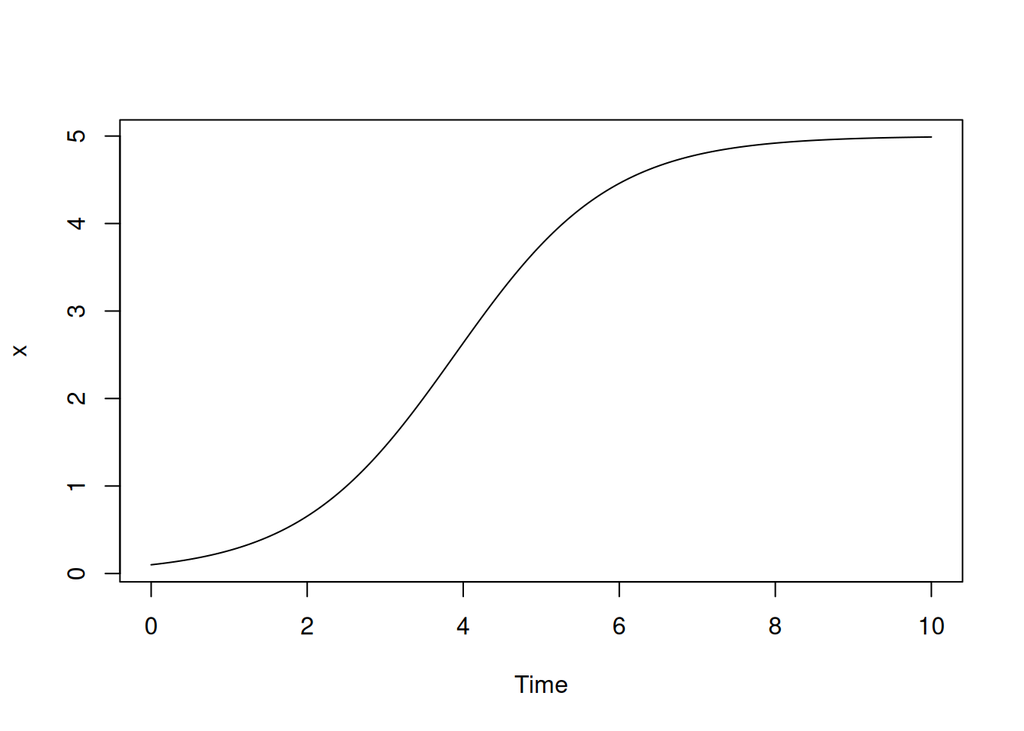

```r
simtimes <- seq(0, 10, by = 0.01)
x.ode <- ode(.growth$xinit, simtimes, growth, .growth)

plot(x.ode[, 1], x.ode[, 2], type = "l", xlab = "Time", ylab = "x")
```

The output from `ode()` is a matrix, the first column of which is the time variable values and the remaining columns are the values of the variables (e.g., $x$) at those times.

# An SDE version

It should be easy for the user to say, “Ok, now show me that with noise!” Unfortunately, it’s not that easy. Enter the *localsolver* package. *localsolver* provides a function, `sde()`, which attemps to make the transition from ODE to SDE as seamless as possible. We are now interested in the following model:

$dx = (rx(1 - \frac{x}{K}))dt + d\sigma W$

I hope I have written that correctly. In any case, our observable $x$ is a sum of a deterministic process (i.e., $rx(1 - \frac{x}{K})$ and a noise process $W$ with strength (standard deviation) $\sigma$. We can no longer rely on *deSolve*’s machinery to compute our answer for us, so `sde()` uses the brute force method to simulate each time step based on the initial conditions and each time step before the current one. Thus, `sde()` requires that you also specify the first and last time step, the $\Delta t$, and the noise strength $\sigma$. Our simulation code now looks like this:

```r
library(localsolver)

.growth$sigma <- 0.1
control <- list(times = 0:10, deltaT = 0.01)

x.sde <- sde(.growth$xinit, control$times, growth, .growth, control)
```

Note that we are still using `.growth` and `growth()` from before. Additionally, we can pass a sequence of times—this is because I found it easier to think about time that way.

Let’s plot the two results together:

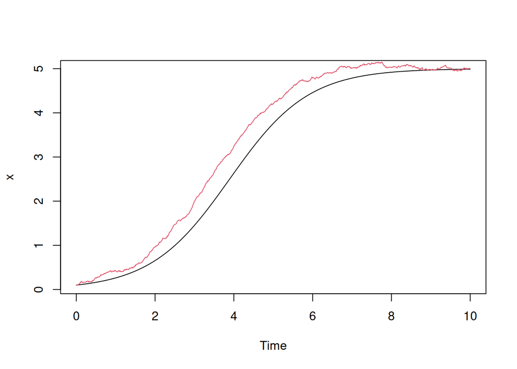

```r
plot(x.ode[, 1], x.ode[, 2], type = "l", xlab = "Time", ylab = "x")
lines(x.sde[, 1], x.sde[, 2], type = "l", col = 2)
```

# Brownian motion

Sometimes we need more than one variable. When the system can be modeled as a set of coupled single-variable systems, we can use an adjacency matrix method—more on that below. If each node in our system must be described by more than one variable, however, we need a different workflow, demonstrated in this section.

Let’s look first at 1-dimensional Brownian motion with no drift:

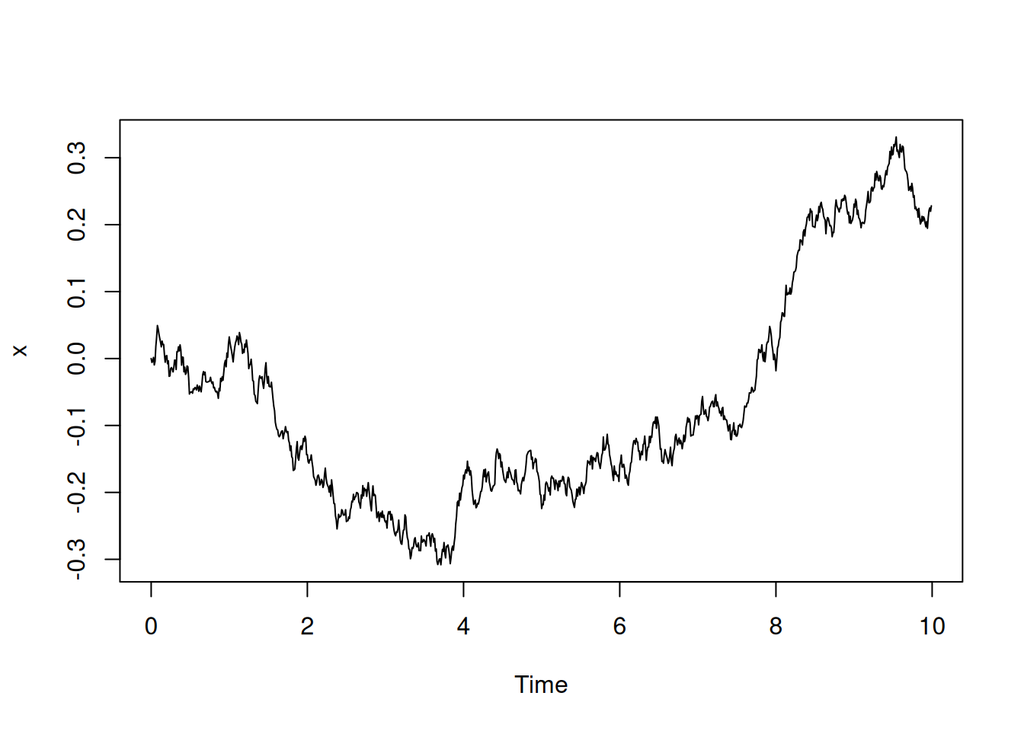

```r
.Brownian1D <- list(xinit = 0, mu = 0, sigma = 1e-1)
Brownian1D <- function(t, x, params) {
    with(params, {
        dx <- mu*x
        return(list(dx))
    })
}

x <- sde(.Brownian1D$xinit, control$times, Brownian1D, .Brownian1D, control)
plot(x[, 1], x[, 2], type = "l", xlab = "Time", ylab = "x")
```

Note that our workflow is very similar—all we’ve had to do is write a different deterministic part of the model.

To make a 2-dimensional Brownian motion model we need to use a trick recommended in the *deSolve* documentation, as follows:

```r
.Brownian2D <- list(xinit = c(y = 0, z = 0), mu = 0, sigma = 1e-1, N = 1, nstatevars = 2)
Brownian2D <- function(t, x, params) {
    with(params, {
        y <- x[1:N]
        z <- x[(N+1):(2*N)]

        dy <- mu*y
        dz <- mu*z
        return(list(dy, dz))
    })
}

res <- sde(.Brownian2D$xinit, control$times, Brownian2D, .Brownian2D, control)
```

Our “derivative” now is the concatenation of the derivatives for our two variables. We can plot our result over time

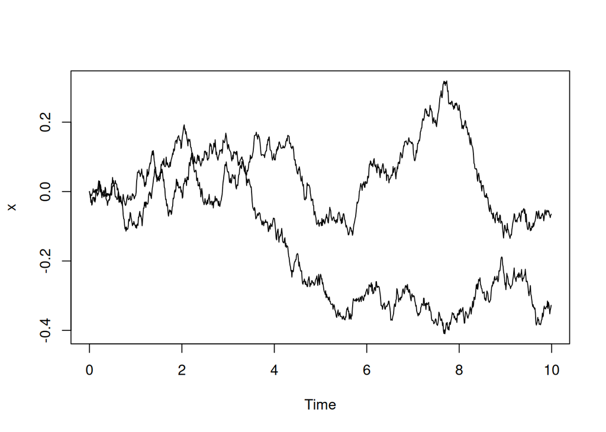

```r
matplot(res[, 1], res[, 2:3], type = "l", lty = 1, col = 1, lwd = 1, xlab = "Time", ylab = "x")
```

or showing the bivariate random walk:

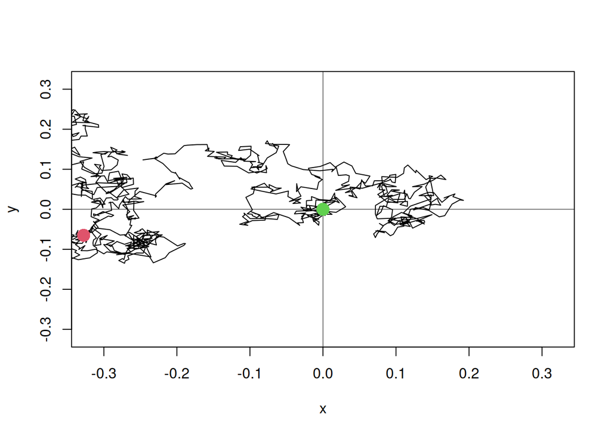

```r
xlim <- ylim <- c(-max(res[, 2:3]), max(res[, 2:3]))
plot(NULL, xlim = xlim, ylim = ylim, xlab = "x", ylab = "y")
abline(h = 0, lwd = 0.5)
abline(v = 0, lwd = 0.5)
lines(res[, 2], res[, 3])
points(res[1, 2], res[1, 3], col = 3, pch = 16, cex = 2) # starting point
points(res[nrow(res), 2], res[nrow(res), 3], col = 2, pch = 16, cex = 2) # stopping point
```

# The guts

My `sde()` function is a brute force simulator, using the derivative function (the deterministic part) to simulate each next state from the previous state. A trick, suggested by the *sde* package, is to generate all the random numbers ahead of time. This improves the computation speed. Thus, *localsolver* includes some helper functions (`determine_ntimesteps()`, `preallocate_noise()`) which are called by `sde()` and enable the user to remain in the model space and user time units, not worrying so much about the implementation. Solving SDEs with *localsolver* will be slower than solving ODEs with *deSolve*, but hopefully it won’t be more confusing.

# Dynamics on networks

If we want to simulate dynamics on networks, we often have a model that looks something like this:

$\frac{dx}{dt} = -(x - r_1)(x - r_2)(x - r_3) + D\sum_{j=1}^N a_{i,j}x_j$

The first part of the model is some nonlinear dynamics (here, a cubic function of $x$) and a coupling function. Here, $D$ can be thought of a coupling strength, so the coupling function simply sums the states of all of node $i$’s neighbors, scaled by $D$. To implement this in *localsolver* as an SDE, we might do something like this:

```r
.doublewell <- list(
    xinit.low = 1, xinit.high = 5,
    r = c(1, 3, 5),
    D = 0.05, Ds = seq(0, 1, length.out = lout),
    u = 0, us.up = seq(0, 5, length.out = lout), us.down = seq(0, -5, length.out = lout),
    sigma = 1e-2,
    lower.basin.limit = 2, upper.basin.limit = 4
)

doublewell <- function(t, x, params) {
    with(params, {
        coupling <- D*rowSums(A*outer(rep(1, length(x)), x))
        dx <- -(x - r[1])*(x - r[2])*(x - r[3]) + coupling + u
        return(list(c(dx)))
    })
}
```

Both `.doublewell` and `doublewell()` are included in *localsolver*; `.doublewell` has more information than we need at present. We can simulate the states of the variables in a network for a given level of $D$ as follows:

```r
library(igraph)
g <- largest_component(sample_gnm(10, 20, directed = FALSE, loops = FALSE))
A <- as_adj(g, "both", sparse = FALSE)
N <- vcount(g)

params <- c(.doublewell, list(A = A))
params$sigma <- 0.1 # to make the noise more visible

x.sde <- sde(rep(.doublewell$xinit.low, N), control$times, doublewell, params, control)
```

# Simulating across a control parameter range

When we need to consider the equilibrium state of a system across a range of parameter values, we need to simulate the system many times in almost the same way every time, changing only the one parameter. *localsolver* provides `solve_in_range()` for this purpose.

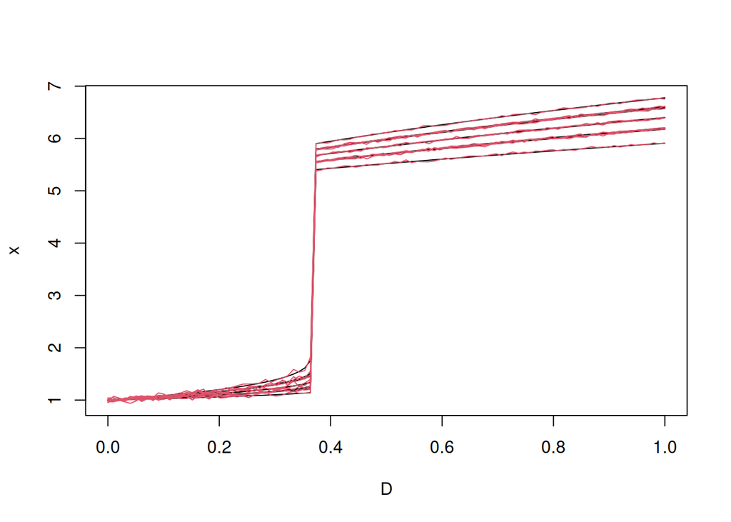

```r
library(parallel) # required for solve_in_range, may not work on Windows
ncores <- detectCores()-1

X.ode <- solve_in_range(params$Ds, "D", doublewell, rep(params$xinit.low, N), params, control, "ode")
X.sde <- solve_in_range(params$Ds, "D", doublewell, rep(params$xinit.low, N), params, control, "sde")

xlim <- range(params$Ds)
ylim <- range(c(X.ode, X.sde))

matplot(
    params$Ds, X.ode, xlim = xlim, ylim = ylim, xlab = "D", ylab = "x", lty = 1, col = 1, lwd = 1, type = "l"
)
matlines(params$Ds, X.sde, lty = 1, col = 2, lwd = 1)
```